# 05-log-transformation

## For each distribution below, generate a figure of the PDF and CDF. Mark the mean and median in the figure.

## For each distribution below, generate a figure of the PDF and CDF of the transformation Y = log(X) random variable. Mark the mean and median in the figure. You may use simulation or analytic methods in order find the PDF and CDF of the transformation.

## For each of the distributions below, generate 1000 samples of size 100. For each sample, calculate the geometric and arithmetic mean. Generate a scatter plot of the geometic and arithmetic sample means. Add the line of identify as a reference line.

## Generate a histogram of the difference between the arithmetic mean and the geometric mean.

## Gamma Cdf & Pdf

```r
x=seq(0.1,20,0.001)
yvalue<-dgamma(x,3,1)
x.mean<-3*1
x.median<- qgamma(0.5,3,1)
plot(x,dgamma(x,3,1),main=
       "Gamma Probability Density Function",ylab = "P",xlab = "x",type = "l") + abline(v=x.mean,col="red") + abline(v=x.median,col="blue")
```

```
## integer(0)
```

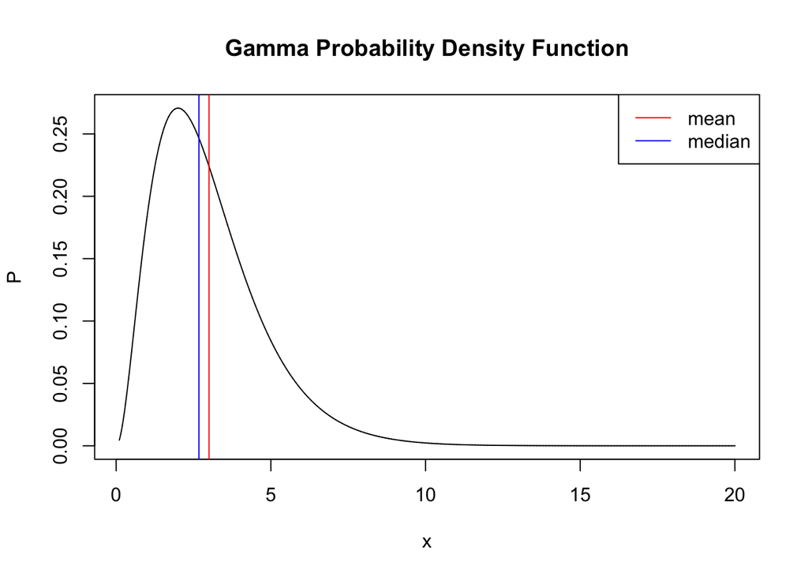

```r
legend("topright",c("mean","median"),col = c("red","blue"),lty = c(1,1))
```

This is the PDF figure for gamma distribution.

```r
x.mean<-3*1
x.median<- qgamma(0.5,3,1)
plot(x,pgamma(x,3,1),main=
       "Gama Cumulative Distribution Function",ylab = "P",xlab = "x",type = "l") + abline(v=x.mean,col="red",labs="m") + abline(v=x.median,col="blue")
```

```
## integer(0)
```

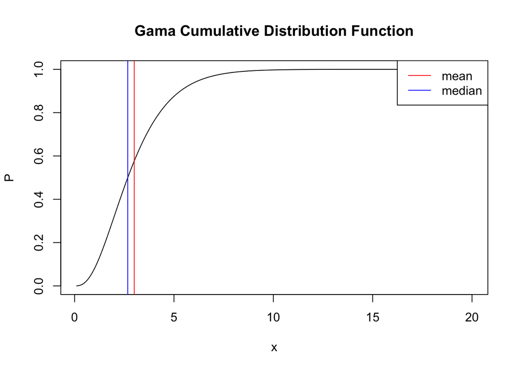

```r
legend("topright",c("mean","median"),col = c("red","blue"),lty = c(1,1))
```

This is the CDF figure for gamma distribution.

```r
x <- rgamma(10000,3,1)
x.mean<-mean(log(x))
x.median<- median(log(x))
plot(density(log(x)),type = "l",main=
       "Gama Log Transformation Probability Density Function",ylab = "P",xlab = "x") + abline(v=x.mean,col="red")+abline(v=x.median,col="blue")
```

```
## integer(0)
```

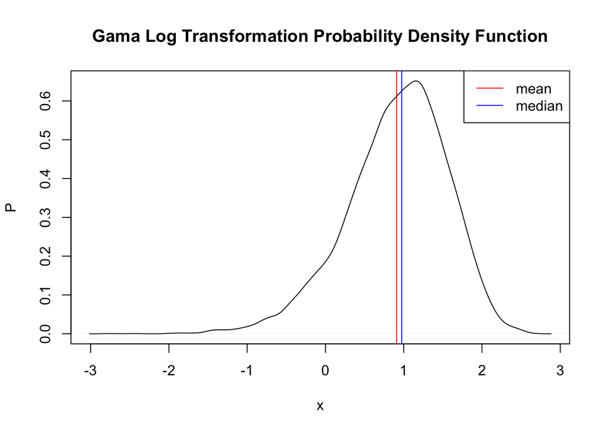

```r
legend("topright",c("mean","median"),col = c("red","blue"),lty = c(1,1))
```

This is the PDF figure for log gamma distribution.

```r
plot(ecdf(log(x)), main= "Gama Log Transformation Cumulative Distribution Function") + abline(v=x.mean,col="red",labs="m") + abline(v=x.median,col="blue")
```

```
## integer(0)
```

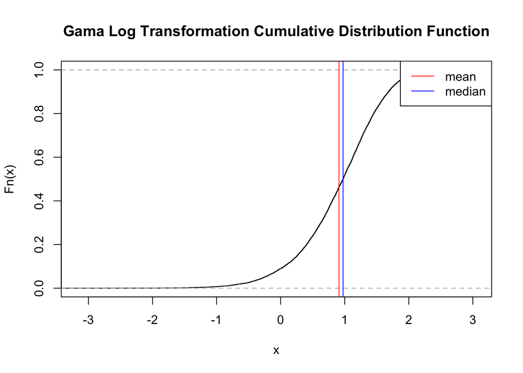

```r
legend("topright",c("mean","median"),col = c("red","blue"),lty = c(1,1))
```

```r
#text(x.mean,"mean")
#text(x.median,"median")
```

This is the CDF figure for log gamma distribution.

## Log Normal Cdf & Pdf

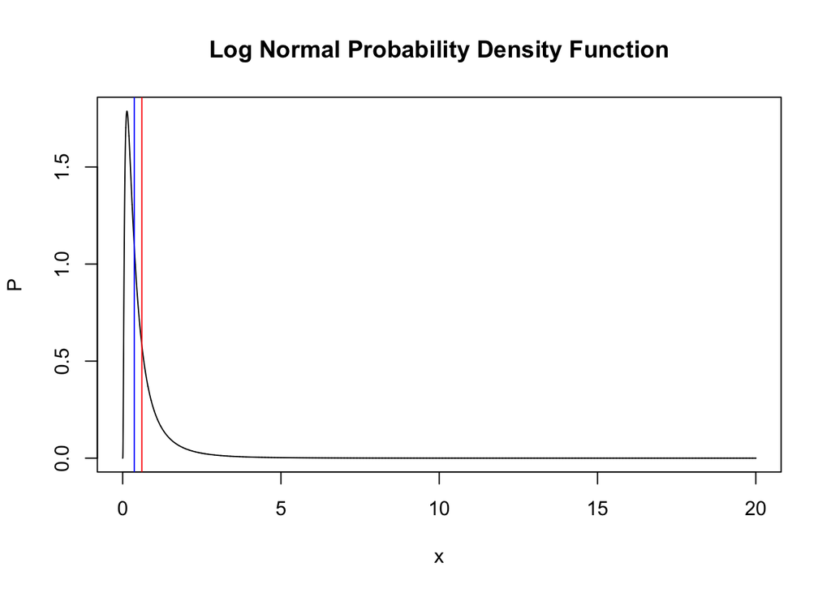

```
## integer(0)
```

```r
x=seq(0,20,0.001)
x.mean<-exp(-1 + 1/2)
x.median<- exp(-1)
plot(x,dlnorm(x,-1,1),main=
       "Log Normal Probability Density Function",ylab = "P",xlab = "x",type = "l") + abline(v=x.mean,col="red",labs="m") + abline(v=x.median,col="blue")
```

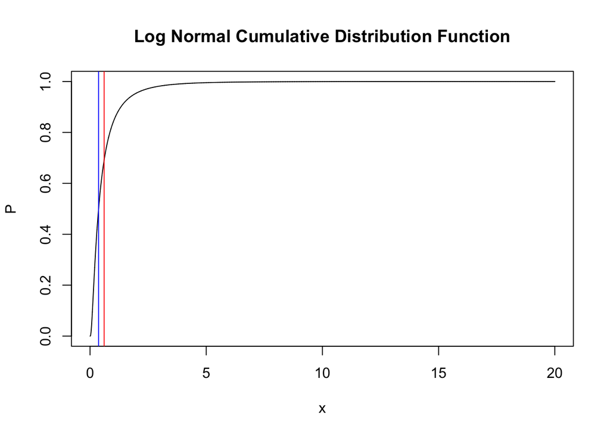

```
## integer(0)
```

```r
plot(x,plnorm(x,-1,1),main=
       "Log Normal Cumulative Distribution Function",ylab = "P",type="l",xlab = "x") + abline(v=x.mean,col="red",labs="m") + abline(v=x.median,col="blue")
```

```r
#x=seq(0,20,0.001)
```

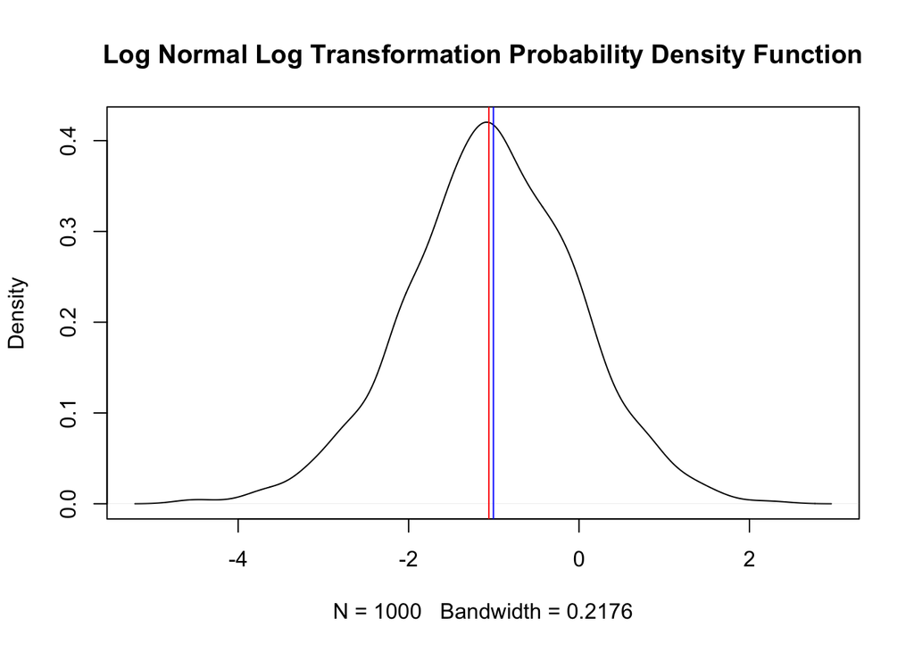

```
## integer(0)
```

```r
x.mean<-mean(log(rlnorm(1000,-1,1)))
x.median<- median(log(rlnorm(1000,-1,1)))
plot(density(log(rlnorm(1000,-1,1))),main=
       "Log Normal Log Transformation Probability Density Function",type = "l") + abline(v=x.mean,col="red",labs="m") + abline(v=x.median,col="blue")
```

This is the PDF figure for log Nomral distribution.

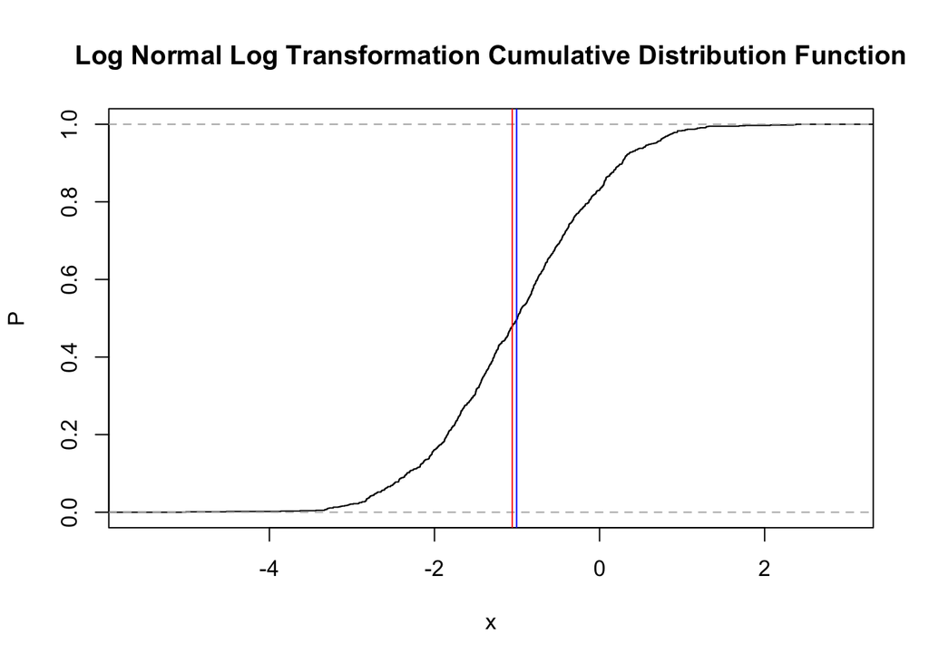

```
## integer(0)
```

```r
plot(ecdf(log(rlnorm(1000,-1,1))),main=
       "Log Normal Log Transformation Cumulative Distribution Function",ylab = "P",xlab = "x") + abline(v=x.mean,col="red",labs="m") + abline(v=x.median,col="blue")
```

```r
#plot(x,plnorm(x,-1,1))
```

This is the CDF figure for log Nomral distribution.

## Uniform Cdf & Pdf

```r
x=seq(0,20,0.001)
x.mean<-(0+12)/2
x.median<- (0+12)/2
plot(x,dunif(x,0,12),main=
       "Uniform Probability Density Function",ylab = "P",xlab = "x",type = "l") + abline(v=x.mean,col="red",labs="m") + abline(v=x.median,col="blue")
```

```
## integer(0)
```

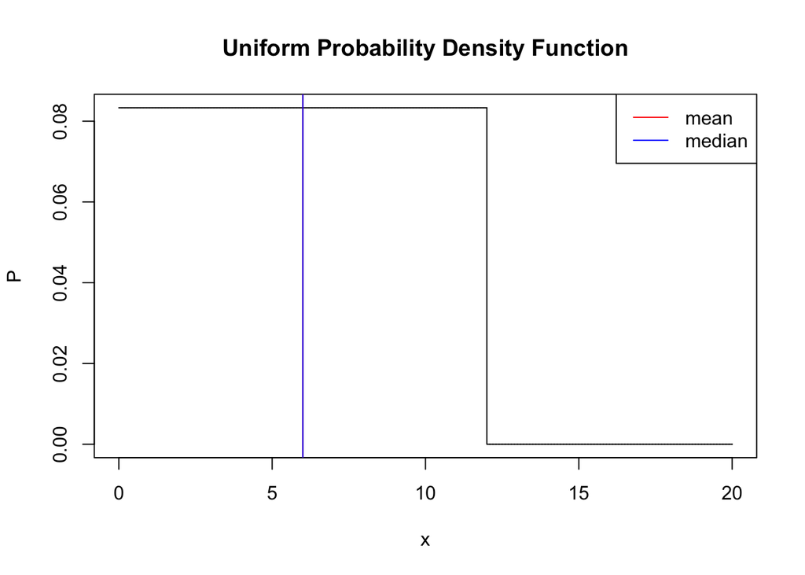

```r
legend("topright",c("mean","median"),col = c("red","blue"),lty = c(1,1))
```

This is the PDF figure for uniform distribution.

```r
plot(x,punif(x,0,12),main=
       "Uniform Cumulative Distribution Function",ylab = "P",type="l",xlab = "x") + abline(v=x.mean,col="red",labs="m") + abline(v=x.median,col="blue")
```

```
## integer(0)
```

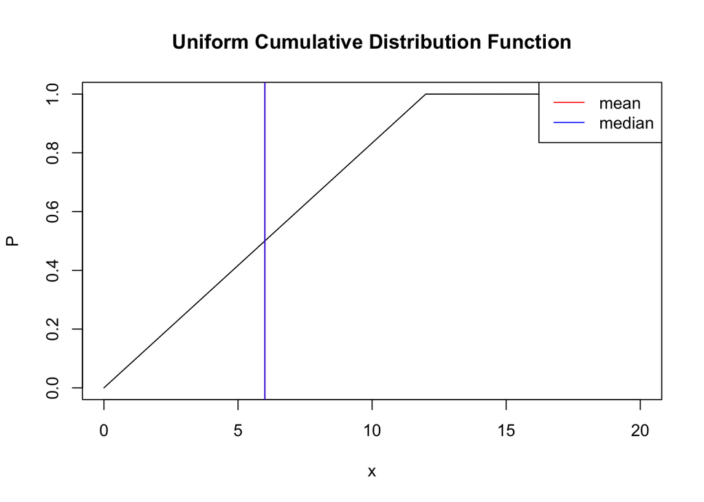

```r
legend("topright",c("mean","median"),col = c("red","blue"),lty = c(1,1))
```

This is the CDF for uniform distribution

```r
x=seq(0,20,0.001)
x.mean<-mean(log(runif(1000,0,12)))
x.median<- median(log(runif(1000,0,12)))
plot(density(log(runif(1000,0,12))),main=
       "Uniform Log Transformation Probability Density Function") + abline(v=x.mean,col="red") + abline(v=x.median,col="blue")
```

```
## integer(0)
```

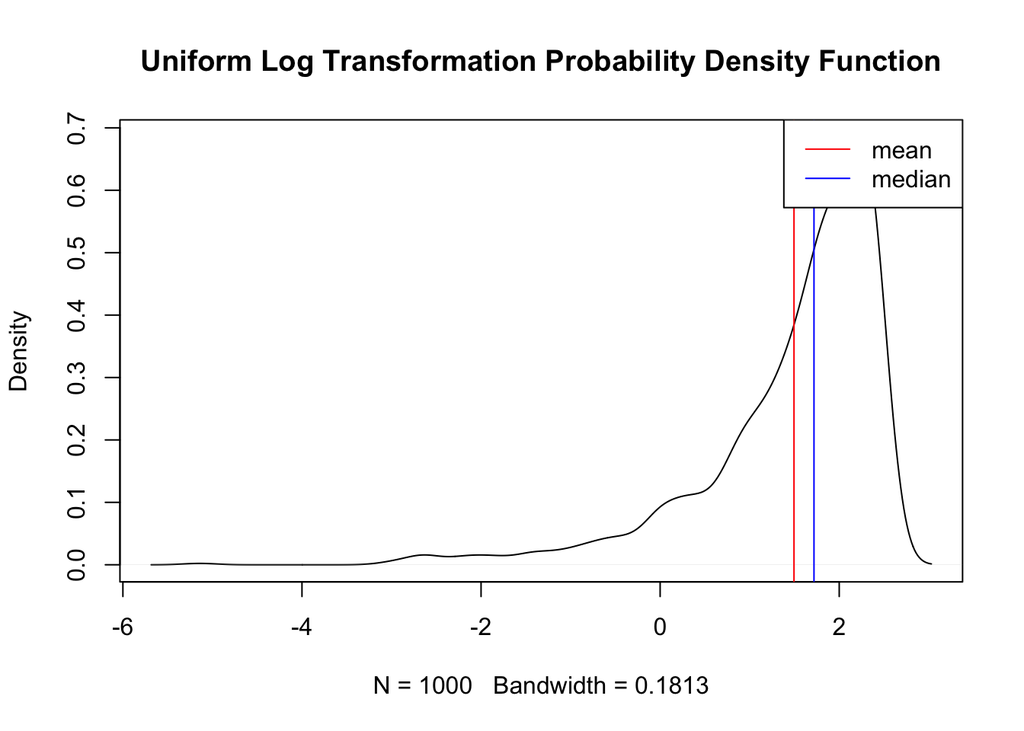

```r
legend("topright",c("mean","median"),col = c("red","blue"),lty = c(1,1))
```

This is the PDF for log uniform distribution.

```r
plot(ecdf(log(runif(1000,0,12))),main=
       "Uniform Log Transformation Cumulative Distribution Function",ylab = "P",xlab = "x") + abline(v=x.mean,col="red") + abline(v=x.median,col="blue")
```

```
## integer(0)
```

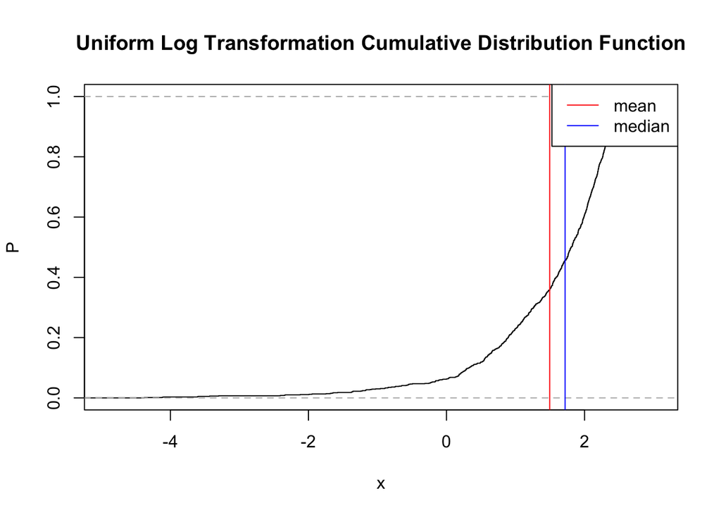

```r
legend("topright",c("mean","median"),col = c("red","blue"),lty = c(1,1))
```

This the CDF for log uniform distribution.

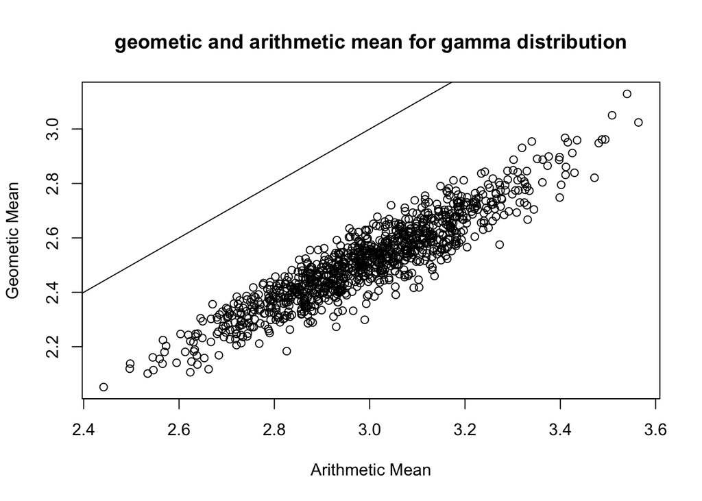

```r
a<-rep(NA,1000)
b<-rep(NA,1000)
for (i in 1:1000) {
        c=rgamma(100,3,1)
        a[i]=mean(c)
        b[i]=exp(mean(log(c)))

}
plot(a,b,main="geometic and arithmetic mean for gamma distribution",xlab="Arithmetic Mean",ylab="Geometic Mean")
abline(0,1)
```

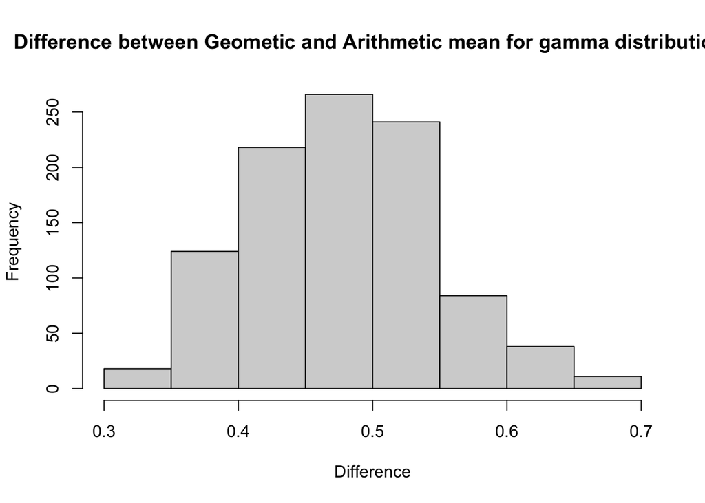

```r
hist(x=(a-b),main="Difference between Geometic and Arithmetic mean for gamma distribution ",xlab="Difference")
```

In this section, we used a loop to simulate the situation. It has a 1000 samples of size 100. Both the geometric and arithmetic mean is ploted in the same graph. The X is arithmetic mean and the y is geometic mean. The histogram shows the difference between them for each individual value.

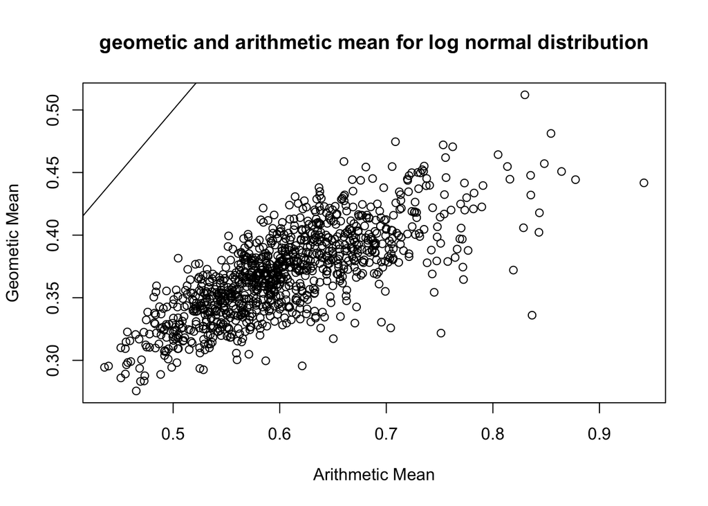

```r
a<-rep(NA,1000)
b<-rep(NA,1000)
for (i in 1:1000) {
        c=rlnorm(100,-1,1)
        a[i]=mean(c)
        b[i]=exp(mean(log(c)))

}
plot(a,b,main="geometic and arithmetic mean for log normal distribution",xlab="Arithmetic Mean",ylab="Geometic Mean")
abline(0,1)
```

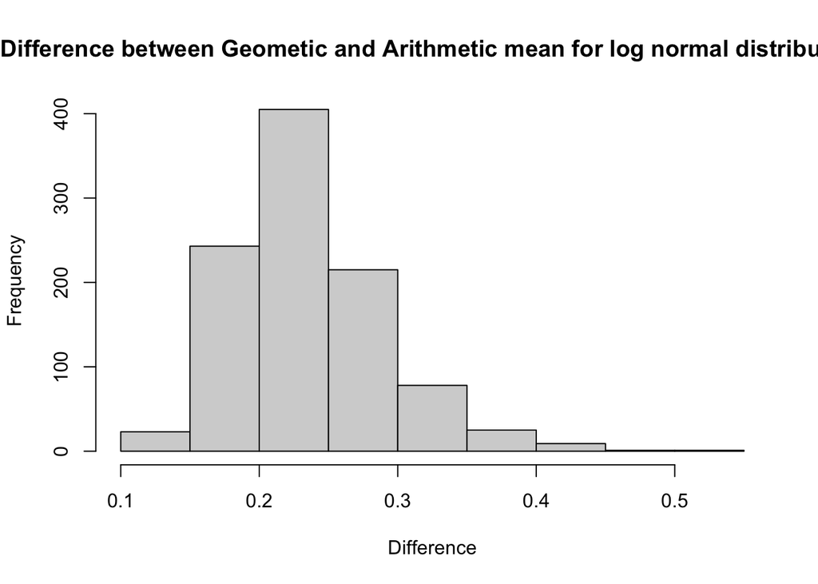

```r
hist(x=(a-b),main="Difference between Geometic and Arithmetic mean for log normal distribution",xlab="Difference")
```

In this section, we used a loop to simulate the situation. It has a 1000 samples of size 100. Both the geometric and arithmetic mean is ploted in the same graph. The X is arithmetic mean and the y is geometic mean. The histogram shows the difference between them for each individual value.

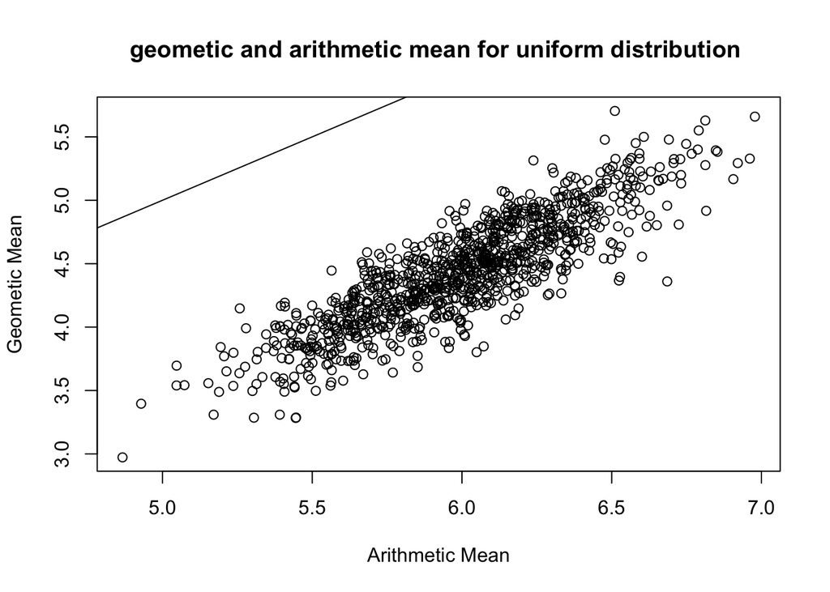

```r
a<-rep(NA,1000)
b<-rep(NA,1000)
for (i in 1:1000) {
        c=runif(100,0,12)
        a[i]=mean(c)
        b[i]=exp(mean(log(c)))

}
plot(a,b,main="geometic and arithmetic mean for uniform distribution ",xlab="Arithmetic Mean",ylab="Geometic Mean")
abline(0,1)
```

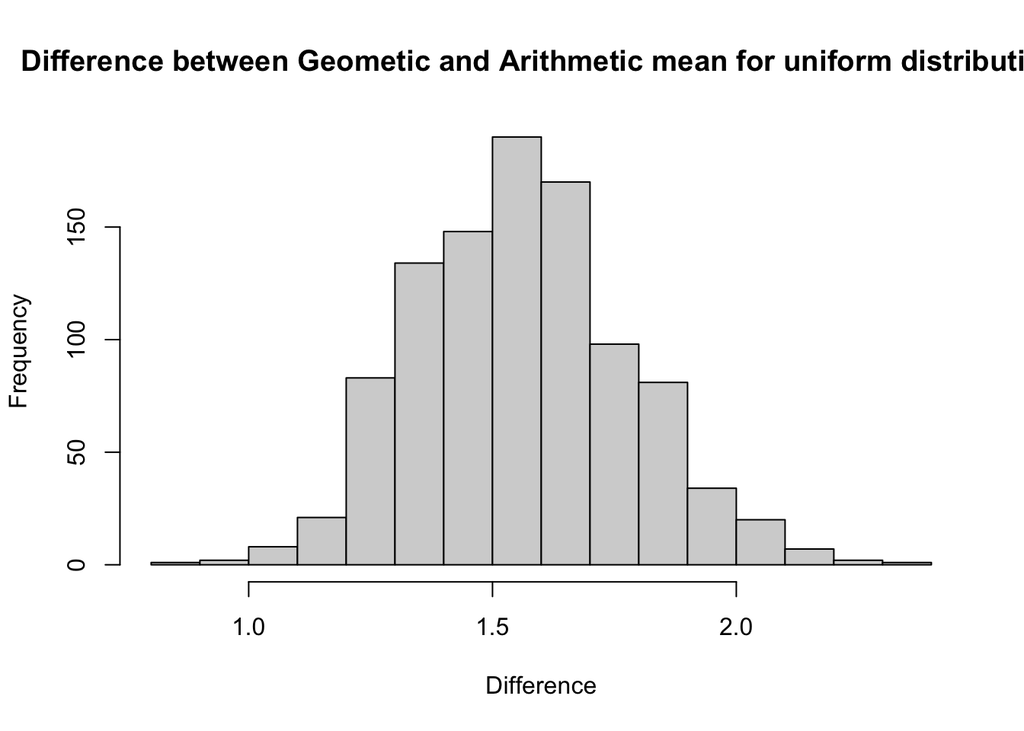

```r
hist(x=(a-b),main="Difference between Geometic and Arithmetic mean for uniform distribution",xlab="Difference")
```

In this section, we used a loop to simulate the situation. It has a 1000 samples of size 100. Both the geometric and arithmetic mean is ploted in the same graph. The X is arithmetic mean and the y is geometic mean. The histogram shows the difference between them for each individual value.

## part 3

```r
relationship <- function(sample,size){
  a<-rep(NA,size)
  b<-rep(NA,size)
  diff<-rep(NA,size)
  c<-NA
  for (i in 1:size) {
    c=sample(sample,size,replace = TRUE)
    a[i]=log(mean(c))
    b[i]=mean(log(c))
    diff[i]=a[i]-b[i]
  }
  #mean(diff)
  diff
  }
relationship(1000,100)
```

```
##   [1] 0.3308895 0.2587823 0.2973709 0.2360834 0.2999537 0.4259170 0.2788565
##   [8] 0.2648296 0.2784173 0.4587536 0.2636447 0.3094453 0.2519924 0.2462394
##  [15] 0.4293160 0.3227357 0.3471972 0.3750777 0.3107048 0.3823596 0.2464054
##  [22] 0.3338803 0.3066683 0.2825661 0.2664891 0.3072710 0.3549791 0.2407056
##  [29] 0.3447280 0.3867597 0.2549230 0.2974512 0.4040299 0.3305870 0.2341943
##  [36] 0.4238794 0.2956265 0.3132590 0.3024790 0.3123874 0.3665588 0.3347872
##  [43] 0.2117122 0.2348872 0.2315021 0.3754790 0.3466093 0.3456261 0.3020646
##  [50] 0.2990003 0.3634328 0.2714171 0.2984768 0.3610625 0.2944558 0.2091119
##  [57] 0.3496961 0.2867952 0.3145075 0.3243337 0.3181810 0.3663556 0.2905565
##  [64] 0.2972266 0.2662514 0.2853417 0.5173492 0.2708647 0.3152988 0.3640177
##  [71] 0.2896636 0.3089267 0.3217260 0.3197008 0.4131030 0.4519381 0.1476909
##  [78] 0.2446955 0.2789104 0.3342649 0.2781220 0.4078398 0.2244771 0.4170835
##  [85] 0.3126806 0.3579769 0.3785774 0.2463875 0.3987739 0.3815371 0.3513859
##  [92] 0.3095087 0.2455026 0.2340316 0.3042683 0.2613909 0.3697200 0.3342529
##  [99] 0.3428692 0.4275996
```

```r
d<-rep(1,100)
e=log(mean(d))
f=mean(log(d))
e == f
```

```
## [1] TRUE
```